# Milestone Report

N Selva Kumar

10/3/2020

## Synopsis

This Milestone Report is for the Coursera Data Science Capstone project. The goal is to create a predictive text model using a large text corpus of documents as training data.

Natural language processing techniques will be used to perform the analysis and build the predictive model.

This milestone report describes the major features of the training data and summarizes our plans for creating the predictive model. All done through exploratory data analysis(EDA).

## Getting the data

```r
library(tidyverse)
library(stringi)
library(tm)
library(RWeka)
```

```r
# URL for the data
url <- "https://d396qusza40orc.cloudfront.net/dsscapstone/dataset/Coursera-SwiftKey.zip"

if (!file.exists("./data")) {
  dir.create("./data")
}

## Check if zip has been downloaded in given directory?
if(!file.exists("./data/Coursera-SwiftKey.zip")){
  download.file(url,destfile="./data/Coursera-SwiftKey.zip",mode = "wb")
}

## Check if zip has been unzipped
if(!file.exists("./data/final")){
  unzip(zipfile="./data/Coursera-SwiftKey.zip",exdir="./data")
}
```

Once the dataset is downloaded, we need to start reading it. The dataset given is huge and thus it is recommended to read in line by line.

The data sets consist of text from 3 different sources:

**1.** News

**2.** Blogs

**3.** Twitter feeds.

```r
# Path of US datasets
path <- file.path("./data/final" , "en_US")
files<-list.files(path, recursive=TRUE)

# File connection to twitter data set
tweets <- file("./data/final/en_US/en_US.twitter.txt", "r")

twitterLines <-readLines(tweets, skipNul = TRUE)

close(tweets) # Close the connection after done

# File connection to blog data set
blogs <- file("./data/final/en_US/en_US.blogs.txt", "r")

blogLines<-readLines(blogs, skipNul = TRUE)

close(blogs) # Close the connection when done

# File connection of news data set
news <- file("./data/final/en_US/en_US.news.txt", "r")

newsLines<-readLines(news, skipNul = TRUE)
close(news) # Close the connection when done
```

Summary of findings:

*file sizes*

*line counts*

*word counts*

*mean words per line*

```r
# Get file sizes
twitterSize <- file.info("./data/final/en_US/en_US.twitter.txt")$size / 1024 ^ 2

blogSize <- file.info("./data/final/en_US/en_US.blogs.txt")$size / 1024 ^ 2

newsSize <- file.info("./data/final/en_US/en_US.news.txt")$size / 1024 ^ 2

# Get words in files
twitterWords <- stri_count_words(twitterLines)
blogWords <- stri_count_words(blogLines)
newsWords <- stri_count_words(newsLines)
# Summary of the data sets
data.frame(source = c("blogs", "news", "twitter"),
           file.size.MB = c(blogSize,
                            newsSize,
                            twitterSize),

           num.lines = c(length(blogLines),
                         length(newsLines),
                         length(twitterLines)),

           num.words = c(sum(blogWords),
                         sum(newsWords),
                         sum(twitterWords)),

           mean.num.words =c(mean(blogWords),
                             mean(newsWords),
                             mean(twitterWords)))
```

```
##    source file.size.MB num.lines num.words mean.num.words
## 1   blogs     200.4242    899288  38154238       42.42716
## 2    news     196.2775     77259   2693898       34.86840
## 3 twitter     159.3641   2360148  30218166       12.80350
```

## Cleaning The Data

Before EDA, the data has to be cleaned. Involves removal of URLs, special characters, punctuations, numbers, excess whitespace, stopwords, and changing the text to lower case.

Since the data sets are huge, 2% of the data are randomly chosen to demonstrate the data cleaning and exploratory data analysis.

UTF chars have to be taken care of.

```r
set.seed(2020) # Sample data for reproducible results

sample <- c(sample(blogLines, length(blogLines) * 0.02),
                 sample(newsLines, length(newsLines) * 0.02),
                 sample(twitterLines, length(twitterLines) * 0.02))

# Create corpus and clean data
corpus <- VCorpus(VectorSource(sample))

toSpace <- content_transformer(function(x, pattern) gsub(pattern, " ", x))

corpus <- tm_map(corpus, toSpace, "(f|ht)tp(s?)://(.*)[.][a-z]+")
corpus <- tm_map(corpus, toSpace, "@[^\\s]+")
corpus <- tm_map(corpus, tolower)
corpus <- tm_map(corpus, removeWords, stopwords("en"))
corpus <- tm_map(corpus, removePunctuation)
corpus <- tm_map(corpus, removeNumbers)
corpus <- tm_map(corpus, stripWhitespace)
corpus <- tm_map(corpus, PlainTextDocument)
```

## Exploratory Data Analysis

EDA is conducted on the data.

Find the most frequently occurring words in the data.

Common (n-grams) uni-grams, bi-grams, and tri-grams.

```r
options(mc.cores=1)

# Unigram
unigram<-function(x) NGramTokenizer(x,Weka_control(min=1,max=1))
unigramtab<-TermDocumentMatrix(corpus,control=list(tokenize=unigram))
unigramcorpus<-findFreqTerms(unigramtab,lowfreq=1000)
unigramcorpusnum<-rowSums(as.matrix(unigramtab[unigramcorpus,]))
unigramcorpustab<-data.frame(Word=names(unigramcorpusnum),frequency=unigramcorpusnum)
unigramcorpussort<-unigramcorpustab[order(-unigramcorpustab$frequency),]

# Bigram
bigram<-function(x) NGramTokenizer(x,Weka_control(min=2,max=2))
bigramtab<-TermDocumentMatrix(corpus,control=list(tokenize=bigram))
bigramcorpus<-findFreqTerms(bigramtab,lowfreq=80)
bigramcorpusnum<-rowSums(as.matrix(bigramtab[bigramcorpus,]))
bigramcorpustab<-data.frame(Word=names(bigramcorpusnum),frequency=bigramcorpusnum)
bigramcorpussort<-bigramcorpustab[order(-bigramcorpustab$frequency),]

# Trigram
trigram<-function(x) NGramTokenizer(x,Weka_control(min=3,max=3))
trigramtab<-TermDocumentMatrix(corpus,control=list(tokenize=trigram))
trigramcorpus<-findFreqTerms(trigramtab,lowfreq=10)
trigramcorpusnum<-rowSums(as.matrix(trigramtab[trigramcorpus,]))
trigramcorpustab<-data.frame(Word=names(trigramcorpusnum),frequency=trigramcorpusnum)
trigramcorpussort<-trigramcorpustab[order(-trigramcorpustab$frequency),]
```

Histogram of the 20 most common unigrams in the data sample.

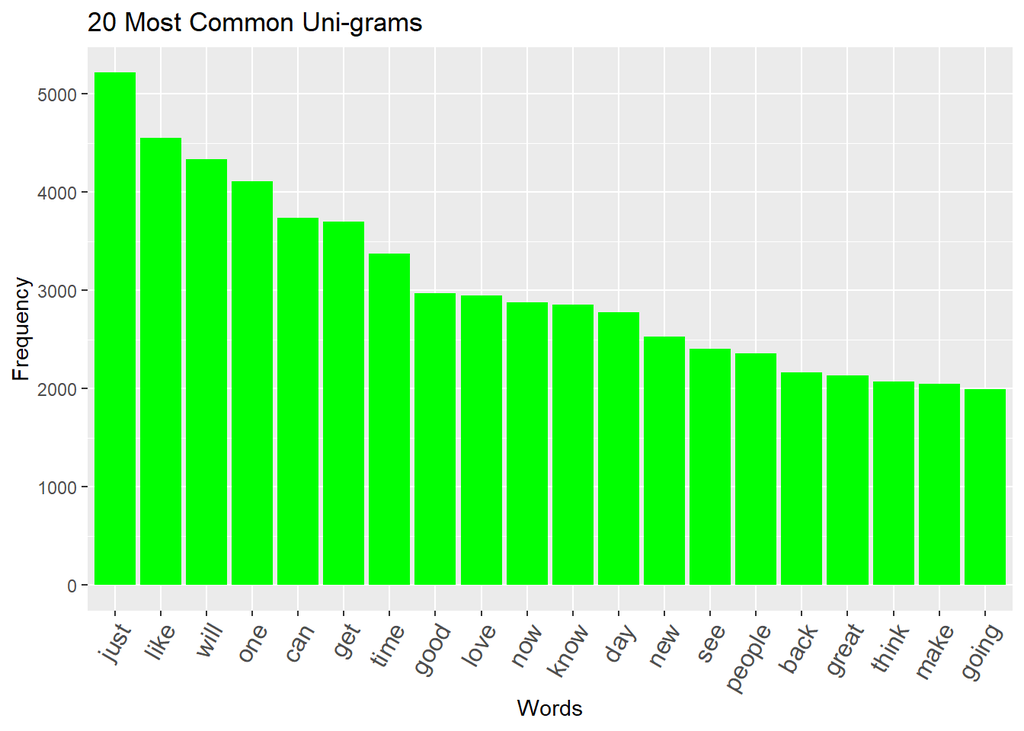

```r
ggplot(unigramcorpussort[1:20,],aes(x=reorder(Word,-frequency),y=frequency))+
    geom_bar(stat="identity",fill = I("green"))+
    labs(title="20 Most Common Uni-grams",x="Words",y="Frequency")+
    theme(axis.text.x=element_text(angle=60, size = 12, hjust = 1))
```

Histogram of the 20 most common bigrams in the data sample.

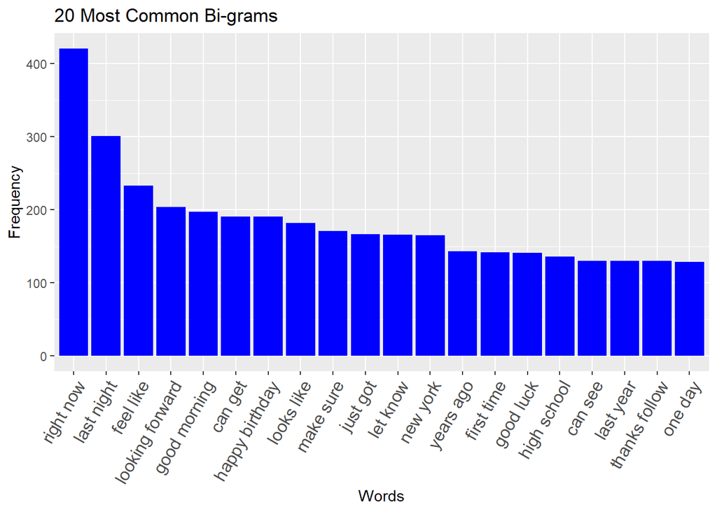

```r
ggplot(bigramcorpussort[1:20,],aes(x=reorder(Word,-frequency),y=frequency))+
    geom_bar(stat="identity",fill = I("blue"))+
    labs(title="20 Most Common Bi-grams",x="Words",y="Frequency")+
    theme(axis.text.x=element_text(angle=60, size = 12, hjust = 1))
```

Histogram of the 20 most common trigrams in the data sample.

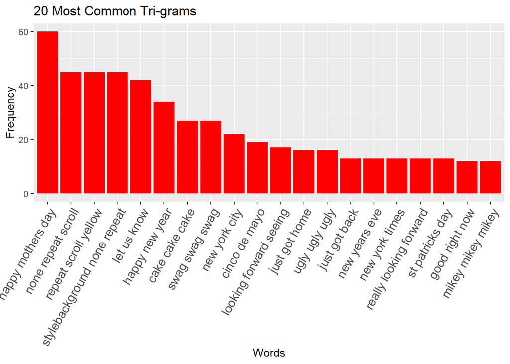

```r
ggplot(trigramcorpussort[1:20,],aes(x=reorder(Word,-frequency),y=frequency))+
    geom_bar(stat="identity",fill = I("red"))+
    labs(title="20 Most Common Tri-grams",x="Words",y="Frequency")+
    theme(axis.text.x=element_text(angle=60, size = 12, hjust = 1))
```

## Conclusion and further planning

This concludes the exploratory data analysis. The next steps would be to finalize the predictive algorithm, and deploy the algorithm as a Shiny app.

The user interface of the Shiny app will consist of a text input box that will allow a user to enter a phrase. Then the app will use our algorithm to suggest the most likely next word.